# TCC_rmd

VILLELA

2022-06-03

```r
library(tidyverse)
library(ggplot2)
library(data.table)
library(ggpubr)
library(cowplot)
library(MASS)
library(gridExtra)
library(nortest)
library(fitdistrplus)
library(geosphere)
library(readxl)
library(rworldmap)
library(rworldxtra) #rworldmap em alta resolução.
library(knitr)
```

Para a criação do Banco de Dados foram coletados dados dos relatórios de Missão SAR dos períodos de 2006 a 2021. Para a coleta foi necessária a leitura dos relatórios individualmente, tendo em vista que alguns relatórios eram documentos digitalizados e ao longo do tempo o padrão dos relatórios foi se modificando. Além disso, cada SALVAERO tinha uma forma de escrever, sendo que as informações das coordenadas de LKP (Last Know Position - úlitma posição conhecida de aeronave), Origem e Destino da aeronave sinistrada e local onde ficou baseada a aeronave que iria realizar a Missão de Busca, por vezes não eram claras ou pior, às vezes eram conflitantes.

Como o escopo do trabalho leva em consideração apenas as buscas sobre a terra, foram excluídas as missões sobre o mar, bem como as missões que não geravam Áreas de Probabilidade Genérica (APG).  
Por exemplo, uma aeronave que possua um TLE (Transmissor Localizador de Emergência) se acidentar e enviar um sinal de emergência que possua uma coordenada GPS, a área de busca será muito pequena, não configurando uma APG.  
Outra situação foi a retirada de casos que tiveram uma investigação, mas as informações estavam muito truncadas, não se tinham determinados dados como LKP ou destino da aeronave.  
Sendo assim, esses casos foram desconsiderados, restando ao final **73 amostras** divididas em 4 regiões de busca (Amazônico, Brasília, Curitiba e Recife), excluída a região do Atlântico por motivos óbvios.

```r
# Importa o Banco de Dados
DF_SAR <- read_excel("C:/Users/andre/OneDrive/Área de Trabalho/CEAO 2022/TCC/PROJETO_TCC/DF_SAR.xlsx")
```

```r
# Coordenada de SBCG
SBCG <- as.numeric(c(-54.66667,-20.46944))
```

Para a mensuração das distâncias, foi usada a biblioteca geosphere e a função DistGeo que considera curvatura da Terra, dando as medidas da forma correta e não considerando um plano cartesiano.

```r
# Pega as coordenadas e mede as distâncias, considerando a superfície da Terra.

# Distância entre Origem e Destino
DF_SAR <- DF_SAR %>%
  mutate((D = distGeo(cbind(DF_SAR$LONG_ORIGEM, DF_SAR$LAT_ORIGEM), cbind(DF_SAR$LONG_DESTINO, DF_SAR$LAT_DESTINO))))

colnames(DF_SAR)[18] <- "Metros_Orig_Dest" # Renomeia a coluna
```

```r
# Transforma de metros para Milhas Náuticas (NM)
DF_SAR <- DF_SAR %>%
  mutate(DF_SAR$Metros_Orig_Dest / 1852)
```

```r
# Muda o nome da coluna
colnames(DF_SAR)[19] <- "Distancia_Orig_Dest"
```

```r
# Distância entre LKP e Destino
DF_SAR <- DF_SAR %>%
  mutate((D = distGeo(cbind(DF_SAR$LONG_LKP, DF_SAR$LAT_LKP),
                      cbind(DF_SAR$LONG_DESTINO, DF_SAR$LAT_DESTINO))))

colnames(DF_SAR)[20] <- "Metros_LKP_Dest"

DF_SAR <- DF_SAR %>%
  mutate(DF_SAR$Metros_LKP_Dest / 1852)

colnames(DF_SAR)[21] <- "Distancia_LKP_Dest"
```

```r
# Distância entre LKP e Base de Operação
DF_SAR <- DF_SAR %>%
  mutate((D = distGeo(cbind(DF_SAR$LONG_LKP, DF_SAR$LAT_LKP), cbind(DF_SAR$LONG_BASE, DF_SAR$LAT_BASE))))
colnames(DF_SAR)[22] <- "Metros_LKP_Base"
DF_SAR <- DF_SAR %>%
  mutate(DF_SAR$Metros_LKP_Base / 1852)
colnames(DF_SAR)[23] <- "Distancia_LKP_Base"
```

```r
# Distância entre LKP e SBCG
DF_SAR <- DF_SAR %>%
  mutate((D = distGeo(cbind(DF_SAR$LONG_LKP, DF_SAR$LAT_LKP), (SBCG))))
colnames(DF_SAR)[24] <- "Metros_LKP_SBCG"
DF_SAR <- DF_SAR %>%
  mutate(DF_SAR$Metros_LKP_SBCG / 1852)
colnames(DF_SAR)[25] <- "Distancia_LKP_SBCG"
```

```r
# Distância entre LKP e SBCG
DF_SAR <- DF_SAR %>%
  mutate((D = distGeo(cbind(DF_SAR$LONG_BASE, DF_SAR$LAT_BASE), (SBCG))))
colnames(DF_SAR)[26] <- "Metros_BASE_SBCG"
DF_SAR <- DF_SAR %>%
  mutate(DF_SAR$Metros_BASE_SBCG / 1852)
colnames(DF_SAR)[27] <- "Distancia_BASE_SBCG"
```

```r
# Excluiu as colunas com distâncias em metros
DF_SAR <- DF_SAR[,-c(18,20,22,24,26)]
```

```r
# Adequando as variáveis
str(DF_SAR)
```

```
## tibble [73 × 22] (S3: tbl_df/tbl/data.frame)
##  $ DATA               : POSIXct[1:73], format: "2021-11-25" "2021-08-06" ...
##  $ ARCC               : chr [1:73] "CW" "AZ" "CW" "AZ" ...
##  $ ORIGEM             : chr [1:73] "SDAM" "PISTA_GRILO" "SSGO" "VILA_SUMAUMA" ...
##  $ LAT_ORIGEM         : num [1:73] -22.85 2.87 -19.42 2.95 2.6 ...
##  $ LONG_ORIGEM        : num [1:73] -47.1 -60.9 -54.6 -61.5 -62.5 ...
##  $ DESTINO            : chr [1:73] "SBJR" "SJLF" "SSAQ" "GARIMPO_1" ...
##  $ LAT_DESTINO        : num [1:73] -22.98 2.48 -28.25 3.62 2.78 ...
##  $ LONG_DESTINO       : num [1:73] -43.4 -63.7 -52.5 -63.7 -60.6 ...
##  $ LAT_LKP            : num [1:73] -23.4 2.53 -19.53 3.53 2.58 ...
##  $ LONG_LKP           : num [1:73] -44.5 -62.7 -54.4 -63.2 -62.5 ...
##  $ LAT_AVISTAMENTO    : chr [1:73] "-23.45" "NA" "-19.533333333333299" "NA" ...
##  $ LONG_AVISTAMENTO   : chr [1:73] "-44.633333333333297" "NA" "-54.4166666666667" "NA" ...
##  $ OBJETO_BUSCA       : chr [1:73] "PP-WRS" "PU-POT" "PU-VVB" "PT-DVB" ...
##  $ TIPO_OBJETO        : chr [1:73] "PA34" "ULTRALEVE" "ULTRALEVE" "C182" ...
##  $ BASE               : chr [1:73] "SBSC" "SBBV" "SBCG" "SBBV" ...
##  $ LAT_BASE           : num [1:73] -22.93 2.84 -20.47 2.84 -3.15 ...
##  $ LONG_BASE          : num [1:73] -43.7 -60.7 -54.7 -60.7 -60 ...
##  $ Distancia_Orig_Dest: num [1:73] 207 170 540 138 118 ...
##  $ Distancia_LKP_Dest : num [1:73] 65.4 60.1 531.6 32.4 113.7 ...
##  $ Distancia_LKP_Base : num [1:73] 49.6 122.9 57.8 155.1 373.1 ...
##  $ Distancia_LKP_SBCG : num [1:73] 595.5 1453.5 57.7 1519.1 1451.6 ...
##  $ Distancia_BASE_SBCG: num [1:73] 628.946 1436.906 0.203 1436.906 1080.715 ...
```

```r
DF_SAR$ARCC <- as.factor(DF_SAR$ARCC)
DF_SAR$ORIGEM <- as.factor(DF_SAR$ORIGEM)
DF_SAR$DESTINO <- as.factor(DF_SAR$DESTINO)
DF_SAR$LAT_AVISTAMENTO <- as.numeric(DF_SAR$LAT_AVISTAMENTO)
DF_SAR$LONG_AVISTAMENTO <- as.numeric(DF_SAR$LONG_AVISTAMENTO)
DF_SAR$TIPO_OBJETO <- as.factor(DF_SAR$TIPO_OBJETO)
DF_SAR$BASE <- as.factor(DF_SAR$BASE)
```

```r
# Separação por Região
DF_AZ <- DF_SAR %>% filter(DF_SAR$ARCC == "AZ")
DF_CW <- DF_SAR %>% filter(DF_SAR$ARCC == "CW")
DF_RE <- DF_SAR %>% filter(DF_SAR$ARCC == "RE")
DF_BS <- DF_SAR %>% filter(DF_SAR$ARCC == "BS")
```

Distribuição do LKP no mapa do Brasil

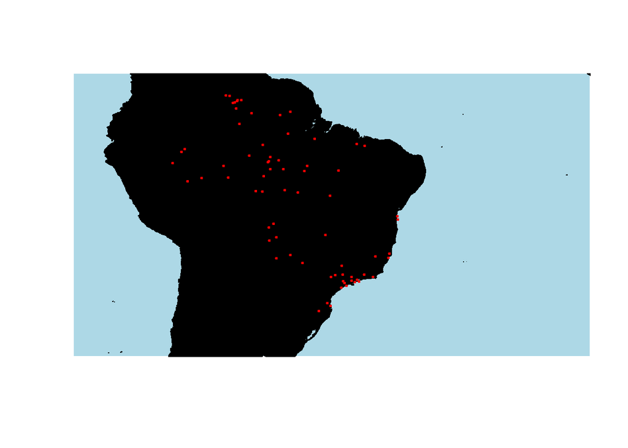

```r
newmap = getMap(resolution = "high")
plot(newmap, #plota o mapa do mundo, cortando nessas coord que eu delimitei.
     xlim = c(-65.98283055, -30.79314722),
     ylim = c(-32.75116944, 5.27438888),
     asp = 1, #razão de aspecto
     bg = "lightblue", #background
     col = "black") #colore o mapa com a cor que eu escolhi.

points(DF_SAR$LONG_LKP, DF_SAR$LAT_LKP,
       col = "red",
       cex = 0.5,
       pch = 20)
```

Utilizando as coordenadas do Banco de Dados, foram medidas as distâncias entre:  
LKP e Destino da aeronave desaparecida  
LKP e Base de Operação da aeronave SAR  
LKP e SBCG  
Base de Operação e SBCG (localidade onde encontra-se o Esquadrão Pelicano - Campo Grande-MS)

# Análise de Distância entre o LKP e o Destino das aeronaves desaparecidas

```r
summary(DF_SAR$Distancia_LKP_Dest)
```

```
##    Min. 1st Qu.  Median    Mean 3rd Qu.    Max.
##   3.415  37.060  65.271 115.918 147.292 565.892
```

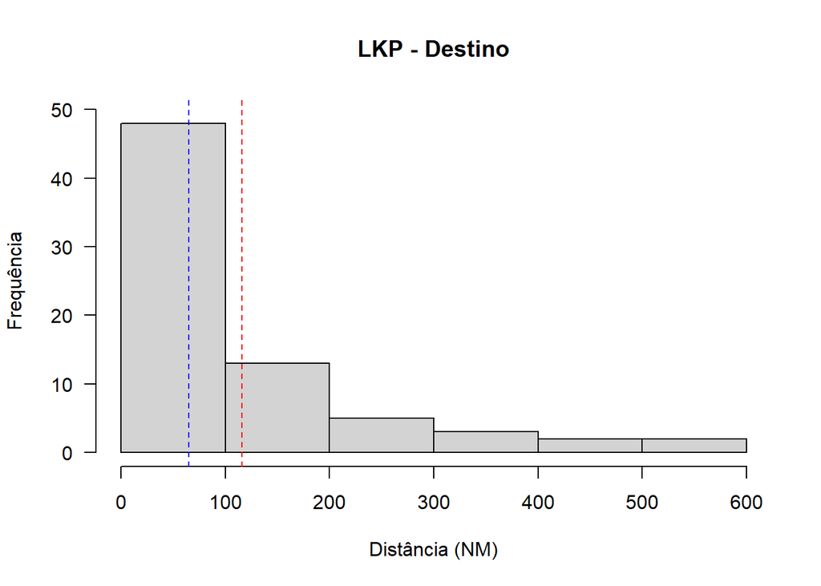

```r
hist(DF_SAR$Distancia_LKP_Dest,
     ylim = c(0,50),
     las = 1,
     main = "LKP - Destino",
     xlab = "Distância (NM)",
     ylab = "Frequência")
abline(v = mean(DF_SAR$Distancia_LKP_Dest), lty = "dashed", col = "red")
abline(v = median(DF_SAR$Distancia_LKP_Dest), lty = "dashed", col = "blue")
```

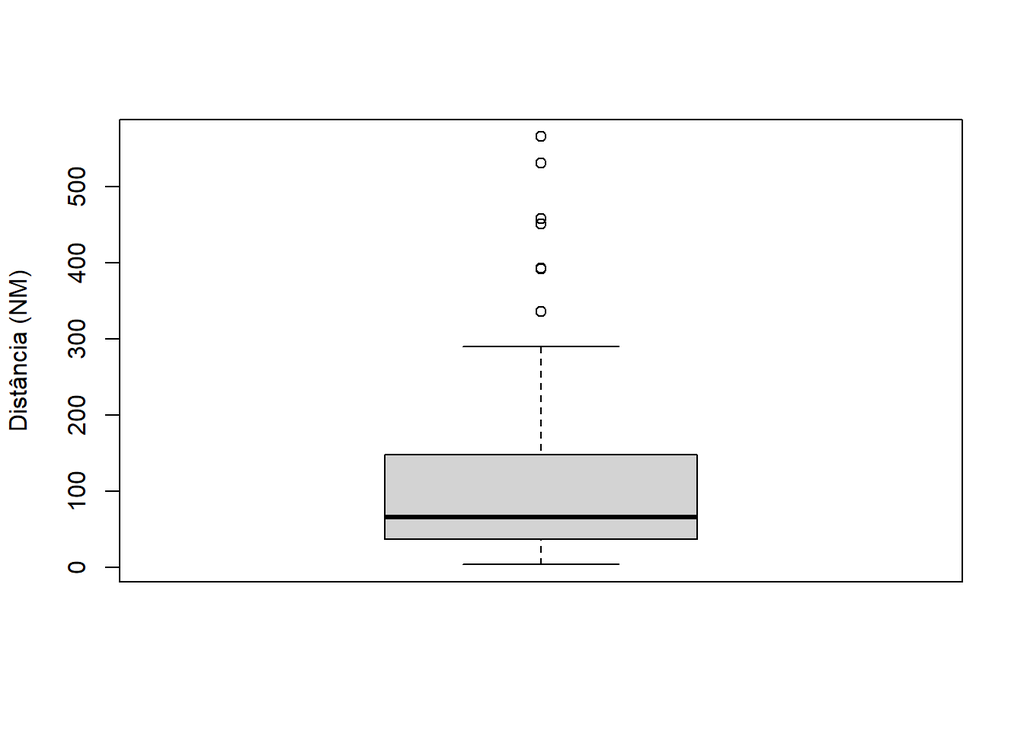

```r
boxplot(DF_SAR$Distancia_LKP_Dest,
        ylab = "Distância (NM)")
```

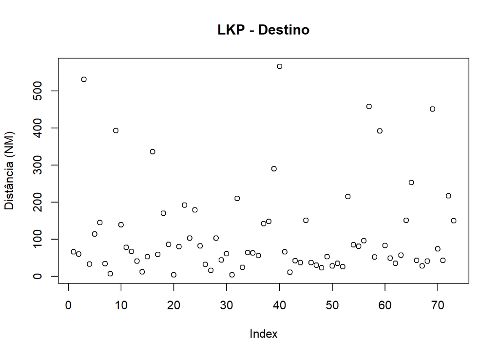

```r
plot(DF_SAR$Distancia_LKP_Dest,
     main = "LKP - Destino",
      ylab = "Distância (NM)")
```

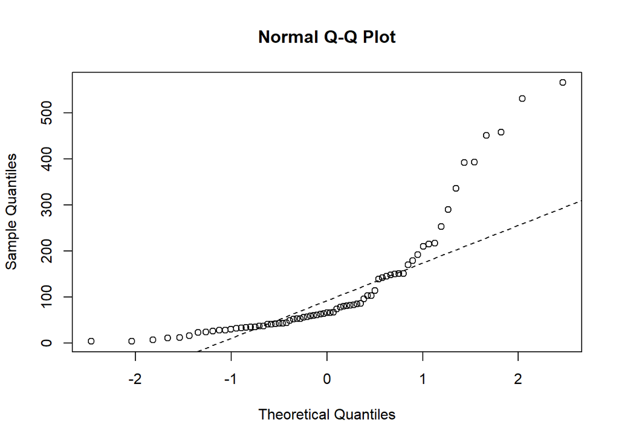

```r
qqnorm(DF_SAR$Distancia_LKP_Dest)
qqline(DF_SAR$Distancia_LKP_Dest, lty="dashed") # adiciona reta que passa pelo 1o. e 3o. quartis
```

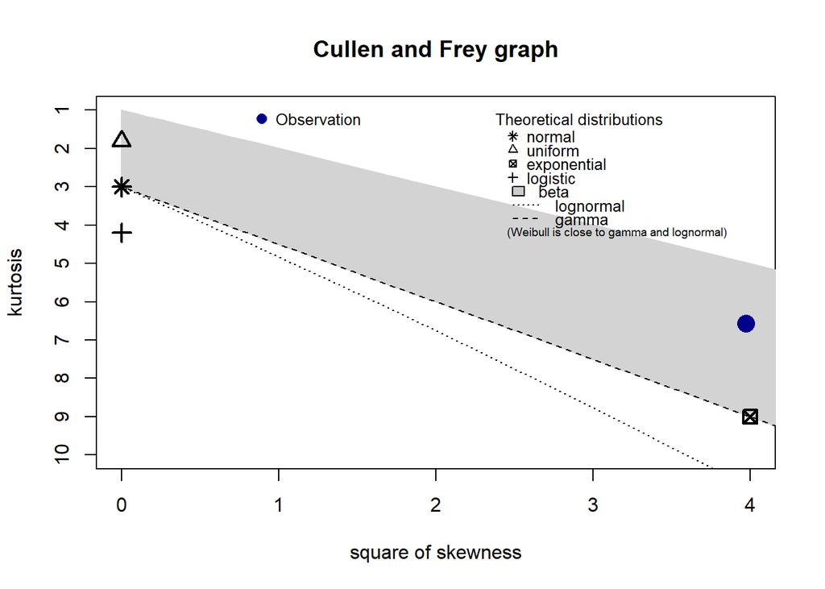

```
## summary statistics
## ------
## min:  3.415241   max:  565.8922
## median:  65.27141
## mean:  115.9185
## estimated sd:  126.785
## estimated skewness:  1.992805
## estimated kurtosis:  6.575581
```

```r
descdist(DF_SAR$Distancia_LKP_Dest)
```

```r
ks.test(DF_SAR$Distancia_LKP_Dest, "pnorm")
```

```
##
##  Exact one-sample Kolmogorov-Smirnov test
##
## data:  DF_SAR$Distancia_LKP_Dest
## D = 0.99968, p-value < 2.2e-16
## alternative hypothesis: two-sided
```

```r
ad.test(DF_SAR$Distancia_LKP_Dest)
```

```
##
##  Anderson-Darling normality test
##
## data:  DF_SAR$Distancia_LKP_Dest
## A = 6.6359, p-value < 2.2e-16
```

```r
shapiro.test(DF_SAR$Distancia_LKP_Dest)
```

```
##
##  Shapiro-Wilk normality test
##
## data:  DF_SAR$Distancia_LKP_Dest
## W = 0.73975, p-value = 4.66e-10
```

```r
lillie.test(DF_SAR$Distancia_LKP_Dest)
```

```
##
##  Lilliefors (Kolmogorov-Smirnov) normality test
##
## data:  DF_SAR$Distancia_LKP_Dest
## D = 0.23701, p-value = 5.334e-11
```

# Análise de Distância entre o LKP e a Base de Operação da aeronave SAR

```r
summary(DF_SAR$Distancia_LKP_Base)
```

```
##    Min. 1st Qu.  Median    Mean 3rd Qu.    Max.
##    0.00   46.26   84.53  106.99  143.12  396.03
```

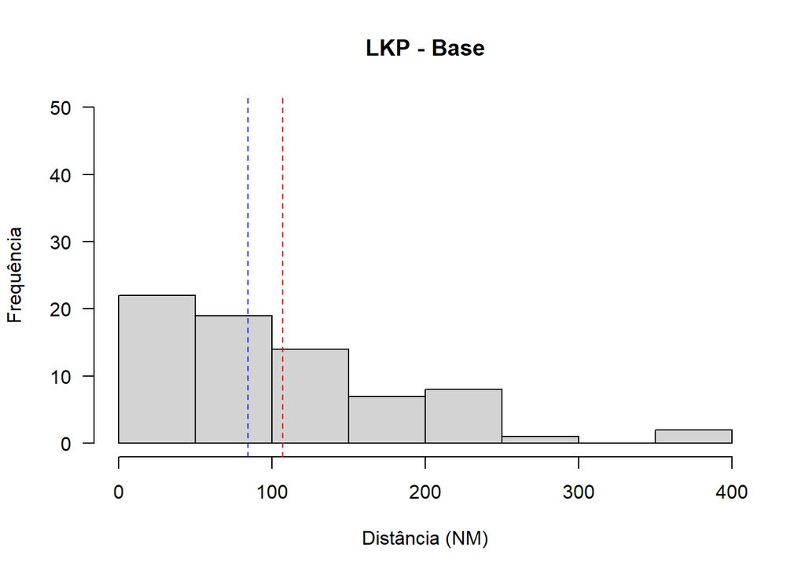

```r
hist(DF_SAR$Distancia_LKP_Base,
     ylim = c(0,50),
     las = 1,
     main = "LKP - Base",
     xlab = "Distância (NM)",
     ylab = "Frequência")
abline(v = mean(DF_SAR$Distancia_LKP_Base), lty = "dashed", col = "red")
abline(v = median(DF_SAR$Distancia_LKP_Base), lty = "dashed", col = "blue")
```

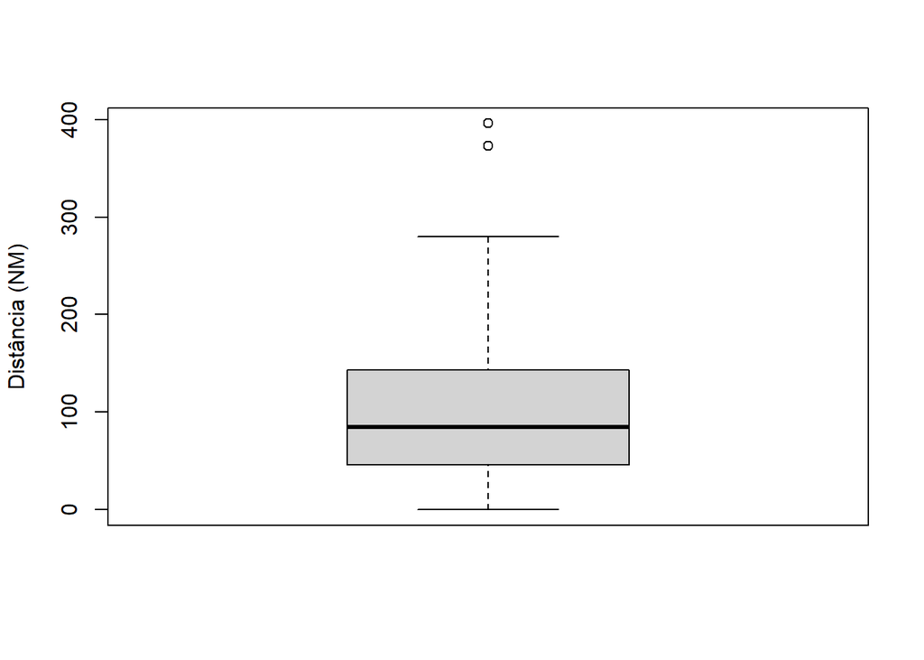

```r
boxplot(DF_SAR$Distancia_LKP_Base,
        ylab = "Distância (NM)")
```

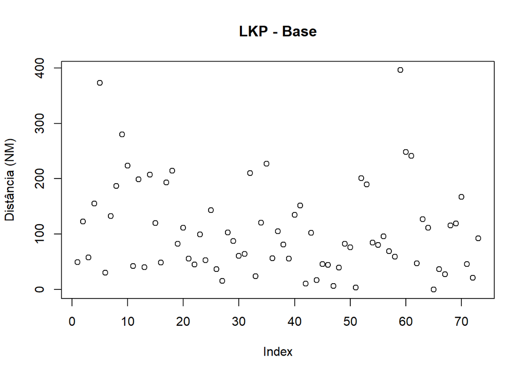

```r
plot(DF_SAR$Distancia_LKP_Base,
     main = "LKP - Base",
      ylab = "Distância (NM)")
```

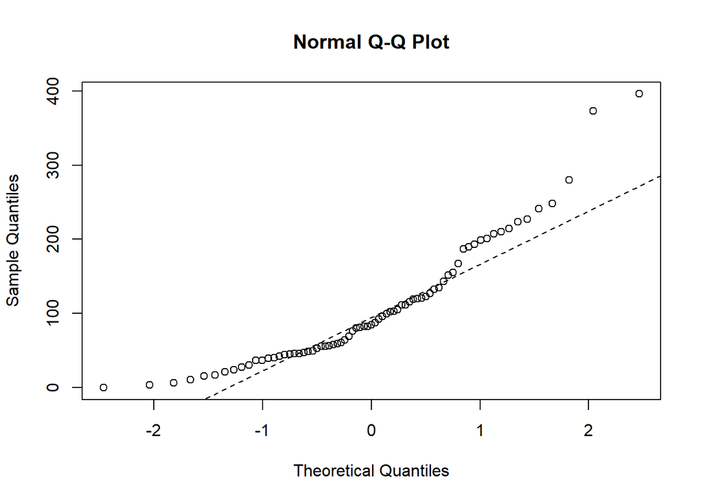

```r
qqnorm(DF_SAR$Distancia_LKP_Base)
qqline(DF_SAR$Distancia_LKP_Base, lty="dashed") # adiciona reta que passa pelo 1o. e 3o. quartis
```

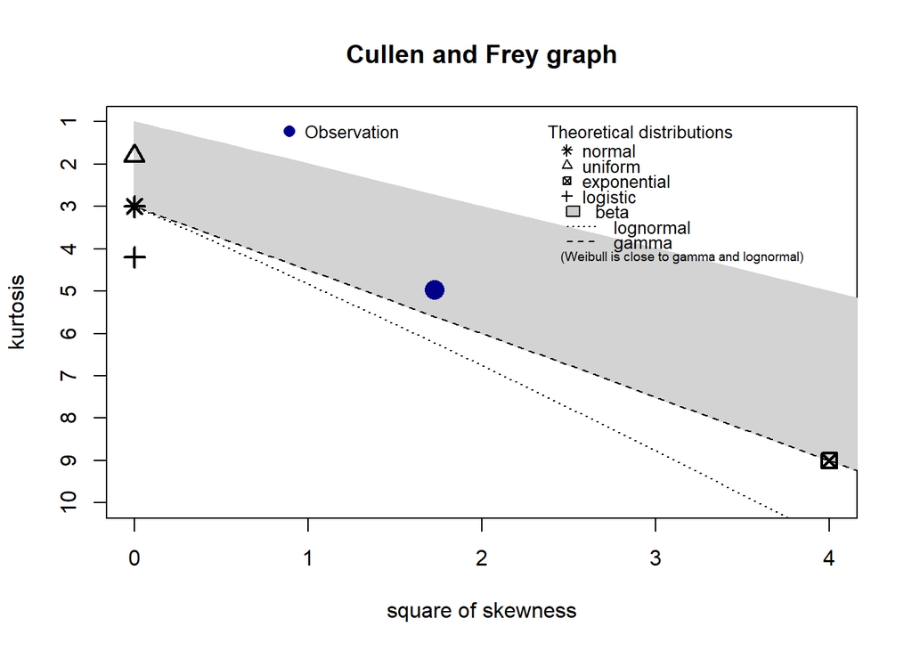

```
## summary statistics
## ------
## min:  0   max:  396.0339
## median:  84.52875
## mean:  106.9925
## estimated sd:  82.57539
## estimated skewness:  1.314529
## estimated kurtosis:  4.959997
```

```r
descdist(DF_SAR$Distancia_LKP_Base)
```

```r
ks.test(DF_SAR$Distancia_LKP_Base, "pnorm")
```

```
##
##  Exact one-sample Kolmogorov-Smirnov test
##
## data:  DF_SAR$Distancia_LKP_Base
## D = 0.986, p-value < 2.2e-16
## alternative hypothesis: two-sided
```

```r
ad.test(DF_SAR$Distancia_LKP_Base)
```

```
##
##  Anderson-Darling normality test
##
## data:  DF_SAR$Distancia_LKP_Base
## A = 2.1301, p-value = 1.826e-05
```

```r
shapiro.test(DF_SAR$Distancia_LKP_Base)
```

```
##
##  Shapiro-Wilk normality test
##
## data:  DF_SAR$Distancia_LKP_Base
## W = 0.89182, p-value = 1.293e-05
```

```r
lillie.test(DF_SAR$Distancia_LKP_Base)
```

```
##
##  Lilliefors (Kolmogorov-Smirnov) normality test
##
## data:  DF_SAR$Distancia_LKP_Base
## D = 0.12208, p-value = 0.008903
```

Tendo em vista que o SMC, teoricamente, escolhe a Base de operação que seja mais próxima da APG, esperava-se que as distâncias fossem menores. Contudo, deve-se considerar duas coisas:  
1- A FAB possui limitação para a escolha da melhor localidade, tendo em vista que nem todos os aeródromos possuem contrato de abastecimento com a FAB, seja por falta de infraestrutura por parte da empresa prestadora de serviço, seja por parte do aerodromo em si que não possui apoio adequado.

2- O SC-105 Amazonas (aeronave de busca) não consegue pousar em qualquer pista, tendo limitação de tamanho da pista e capacidade do pátio suportar o peso da aeronave. Algumas áreas de busca são próximas à pistas de garimpos e não teriam condições de apoio para a tripulação do SC-105.

Assim, essas considerações podem explicar porque as distâncias podem ser grandes, como está apresentado nos gráficos.

Por fim, a média e a mediana são mais próximas do que no item anterior, embora a hipótese de que a distribuição é normal foi rejeitada em todos os testes.

# Análise de Distância entre o LKP e SBCG

```r
summary(DF_SAR$Distancia_LKP_SBCG)
```

```
##    Min. 1st Qu.  Median    Mean 3rd Qu.    Max.
##   57.71  511.64  815.08  818.45 1096.01 1533.52
```

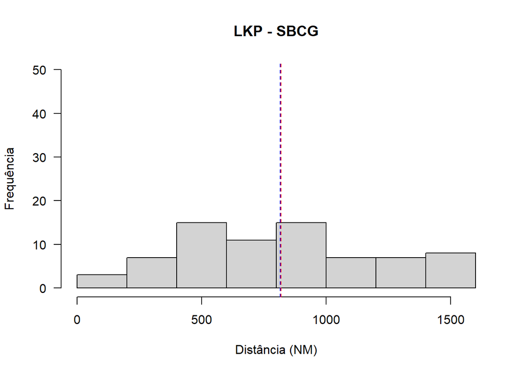

```r
hist(DF_SAR$Distancia_LKP_SBCG,
     ylim = c(0,50),
     las = 1,
     main = "LKP - SBCG",
     xlab = "Distância (NM)",
     ylab = "Frequência")
abline(v = mean(DF_SAR$Distancia_LKP_SBCG), lty = "dashed", col = "red")
abline(v = median(DF_SAR$Distancia_LKP_SBCG), lty = "dashed", col = "blue")
```

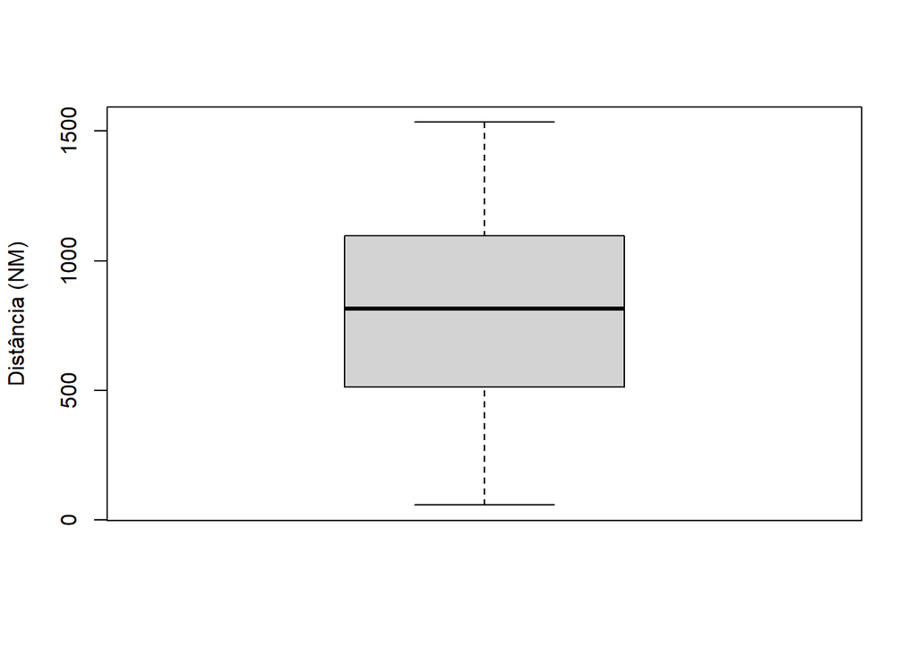

```r
boxplot(DF_SAR$Distancia_LKP_SBCG,
        ylab = "Distância (NM)")
```

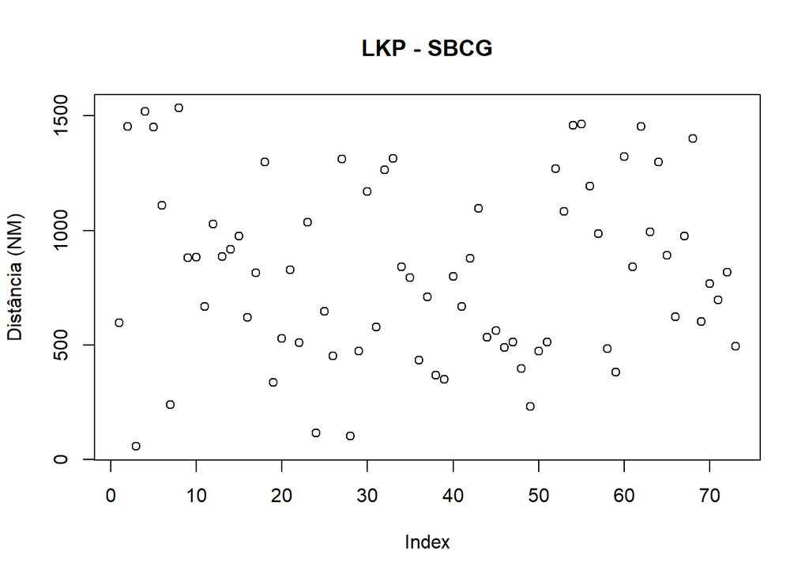

```r
plot(DF_SAR$Distancia_LKP_SBCG,
     main = "LKP - SBCG",
      ylab = "Distância (NM)")
```

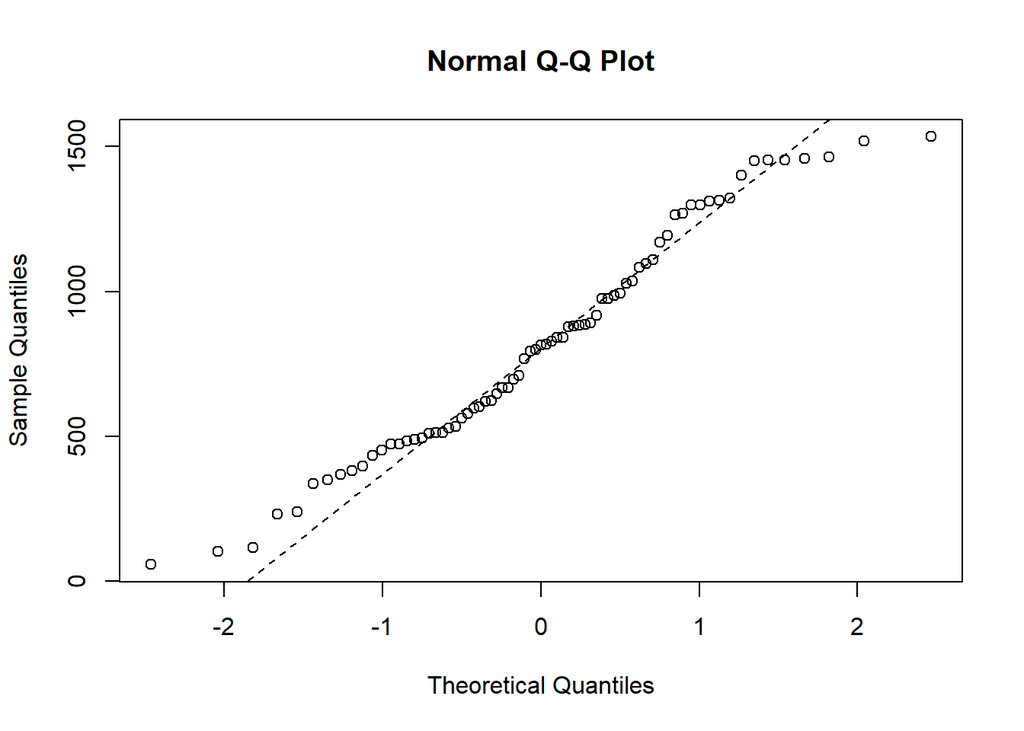

```r
qqnorm(DF_SAR$Distancia_LKP_SBCG)
qqline(DF_SAR$Distancia_LKP_SBCG, lty="dashed") # adiciona reta que passa pelo 1o. e 3o. quartis
```

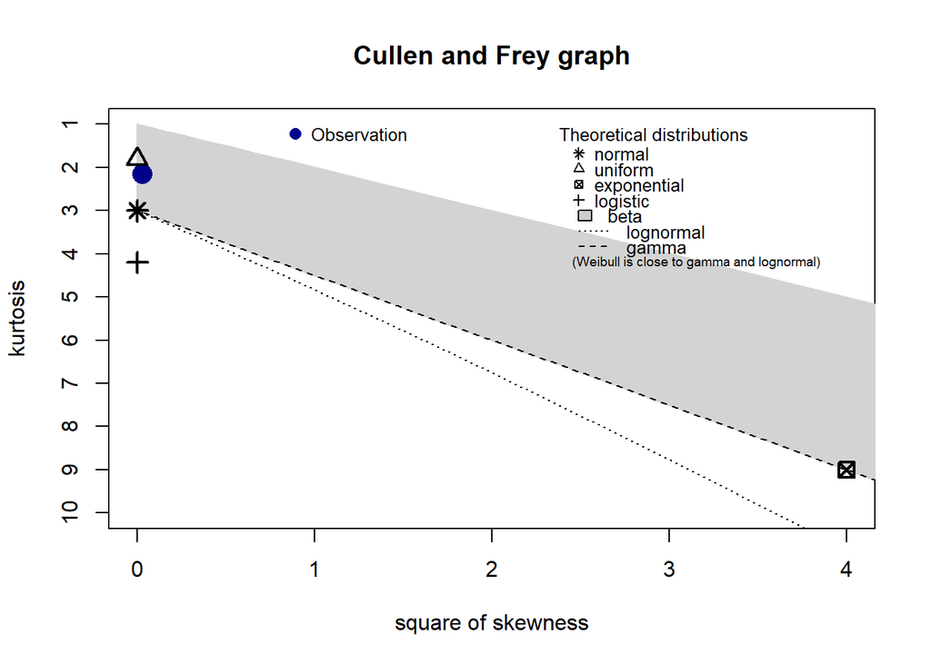

```
## summary statistics
## ------
## min:  57.71181   max:  1533.522
## median:  815.0755
## mean:  818.4499
## estimated sd:  385.1391
## estimated skewness:  0.1613361
## estimated kurtosis:  2.145628
```

```r
descdist(DF_SAR$Distancia_LKP_SBCG)
```

```r
ks.test(DF_SAR$Distancia_LKP_SBCG, "pnorm")
```

```
##
##  Exact one-sample Kolmogorov-Smirnov test
##
## data:  DF_SAR$Distancia_LKP_SBCG
## D = 1, p-value < 2.2e-16
## alternative hypothesis: two-sided
```

```r
ad.test(DF_SAR$Distancia_LKP_SBCG)
```

```
##
##  Anderson-Darling normality test
##
## data:  DF_SAR$Distancia_LKP_SBCG
## A = 0.66391, p-value = 0.07976
```

```r
shapiro.test(DF_SAR$Distancia_LKP_SBCG)
```

```
##
##  Shapiro-Wilk normality test
##
## data:  DF_SAR$Distancia_LKP_SBCG
## W = 0.96779, p-value = 0.05866
```

```r
lillie.test(DF_SAR$Distancia_LKP_SBCG)
```

```
##
##  Lilliefors (Kolmogorov-Smirnov) normality test
##
## data:  DF_SAR$Distancia_LKP_SBCG
## D = 0.081822, p-value = 0.2636
```

Devido às especificidades da Região Amazônica como: menos regiões habitadas, aeronaves de garimpo com manutenção precária e aeronaves de pequeno porte que precisam percorrer grandes distâncias, é uma característica do Brasil que a maioria dos acidentes em terra ocorram nessa região.  
Sendo as regiões de Curitiba e Recife/Atlântico muito envolvidas com acidentes sobre o mar, relacionadas com embarcações ou pessoas à deriva. Por último, têm-se o Salvaero Brasília que está situado em uma região muito povoada, sendo assim, as aeronaves acidentadas não chegam a requerer uma Operação SAR ou Operação de Busca e Salvamento.

Com isso em mente, é natural que a maioria dos acionamentos ocorra de Campo Grande - MS para a região norte do país.

Dessa forma, observa-se uma distribuição praticamente uniforme, sem a presença de outliers, com média e mediana muito próximas, tendo o Esquadrão que percorrer, em média 818NM para chegar ao LKP, para esse intervalo de tempo analisado.

Ressalta-se que os dados tiveram a hipótese nula não rejeitada em todos os testes, com exceção do KS teste.

**Dúvida: por quê só o KS rejeitou? Qual a característica do banco de dados que promoveu esse resultado?**

# Análise de Distância entre SBCG e a Base de Operação

```r
summary(DF_SAR$Distancia_BASE_SBCG)
```

```
##      Min.   1st Qu.    Median      Mean   3rd Qu.      Max.
##    0.2032  517.7827  709.3873  800.5977 1080.7150 1436.9056
```

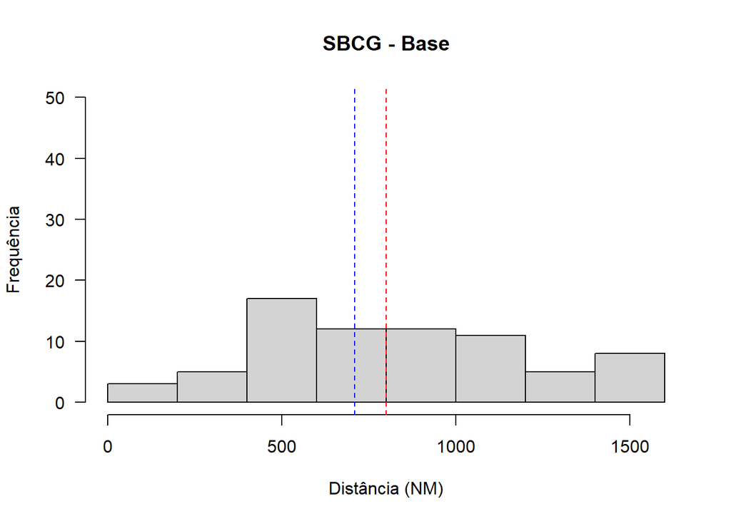

```r
hist(DF_SAR$Distancia_BASE_SBCG,
     ylim = c(0,50),
     las = 1,
     main = "SBCG - Base",
     xlab = "Distância (NM)",
     ylab = "Frequência")
abline(v = mean(DF_SAR$Distancia_BASE_SBCG), lty = "dashed", col = "red")
abline(v = median(DF_SAR$Distancia_BASE_SBCG), lty = "dashed", col = "blue")
```

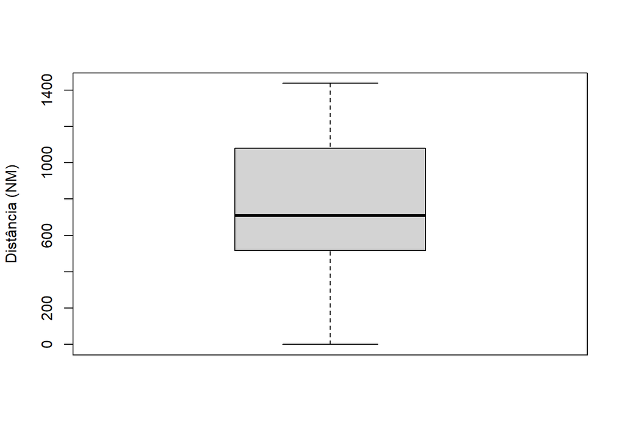

```r
boxplot(DF_SAR$Distancia_BASE_SBCG,
        ylab = "Distância (NM)")
```

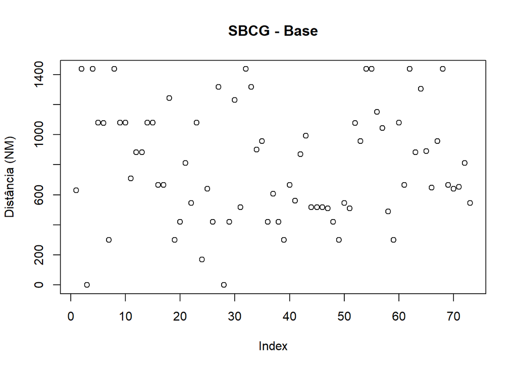

```r
plot(DF_SAR$Distancia_BASE_SBCG,
     main = "SBCG - Base",
      ylab = "Distância (NM)")
```

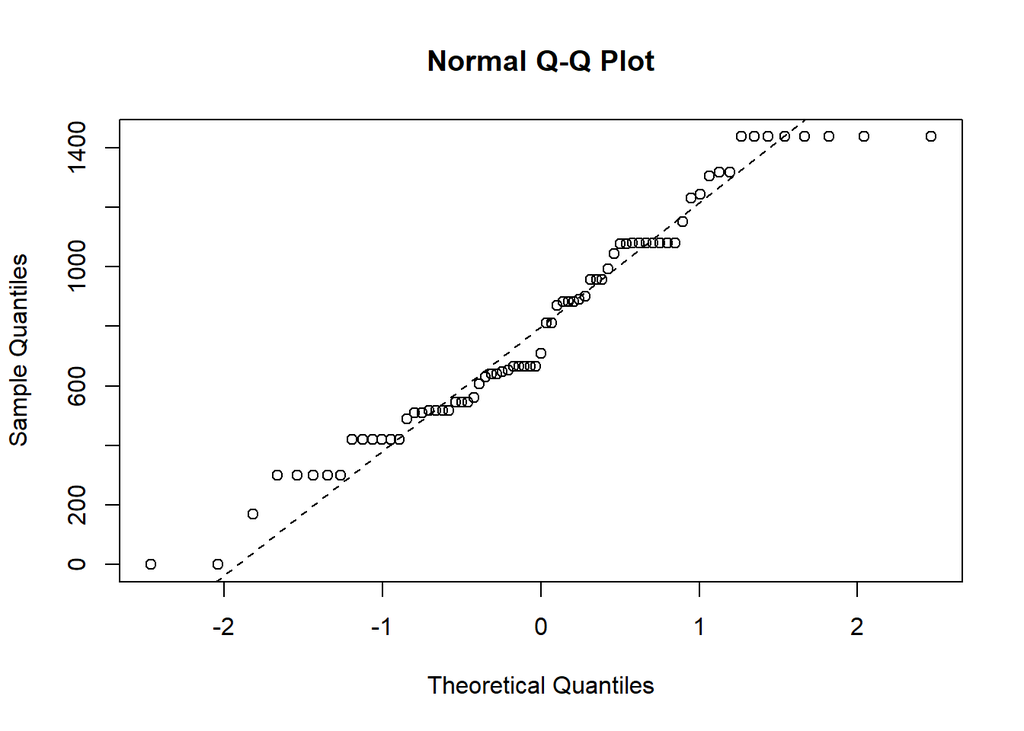

```r
qqnorm(DF_SAR$Distancia_BASE_SBCG)
qqline(DF_SAR$Distancia_BASE_SBCG, lty="dashed") # adiciona reta que passa pelo 1o. e 3o. quartis
```

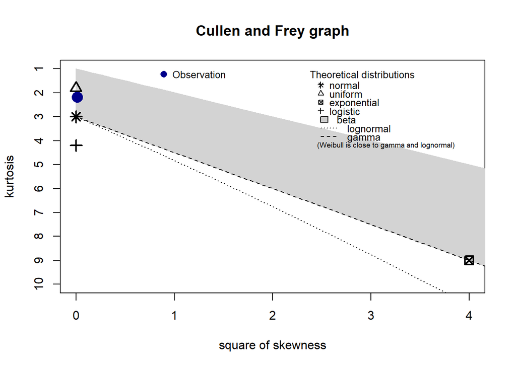

```
## summary statistics
## ------
## min:  0.2032462   max:  1436.906
## median:  709.3873
## mean:  800.5977
## estimated sd:  379.232
## estimated skewness:  0.1044268
## estimated kurtosis:  2.177707
```

```r
descdist(DF_SAR$Distancia_BASE_SBCG)
```

```r
ks.test(DF_SAR$Distancia_BASE_SBCG, "pnorm")
```

```
##
##  Asymptotic one-sample Kolmogorov-Smirnov test
##
## data:  DF_SAR$Distancia_BASE_SBCG
## D = 0.9726, p-value < 2.2e-16
## alternative hypothesis: two-sided
```

```r
ad.test(DF_SAR$Distancia_BASE_SBCG)
```

```
##
##  Anderson-Darling normality test
##
## data:  DF_SAR$Distancia_BASE_SBCG
## A = 0.92719, p-value = 0.0176
```

```r
shapiro.test(DF_SAR$Distancia_BASE_SBCG)
```

```
##
##  Shapiro-Wilk normality test
##
## data:  DF_SAR$Distancia_BASE_SBCG
## W = 0.95825, p-value = 0.01651
```

```r
lillie.test(DF_SAR$Distancia_BASE_SBCG)
```

```
##
##  Lilliefors (Kolmogorov-Smirnov) normality test
##
## data:  DF_SAR$Distancia_BASE_SBCG
## D = 0.13225, p-value = 0.002936
```

Já com relação à distância entre SBCG e a Base de Operação, onde ficará situada a aeronave SAR, a distribuição dos dados não apresenta o mesmo comportamento, com a média e mediana mais afastadas e todos os testes rejeitando a hipótese da distribuição normal. Contudo, não há presença de outliers.

# Teorema Limite Central

Aqui foi uma tentativa de utilizar a Teoria do Limite Central para transformar a distância LKP-Destino (que é a distância a ser utilizada na simulação da rota da aeronave da Base para a APG) em uma distribuição normal. Contudo, em conversa com o professor Mauri, ele achou mais adequado tentar uma transformação primeiro, conforme observado a seguir.

```r
# Uso da Teoria do Limite Central, mas ficou melhor com log.
# APG <- sample(DF_SAR$Distancia_LKP_Dest, size = 50000, replace = T)
# APG <- matrix(APG, nrow = 1000, ncol = 50)
# medias.amostras <- rowMeans(APG)
# hist(medias.amostras)
# ks.test(medias.amostras, "pnorm")
# ad.test(medias.amostras)
# lillie.test(medias.amostras)
```

# Transforção para Log2 da Distância LKP-Dest.

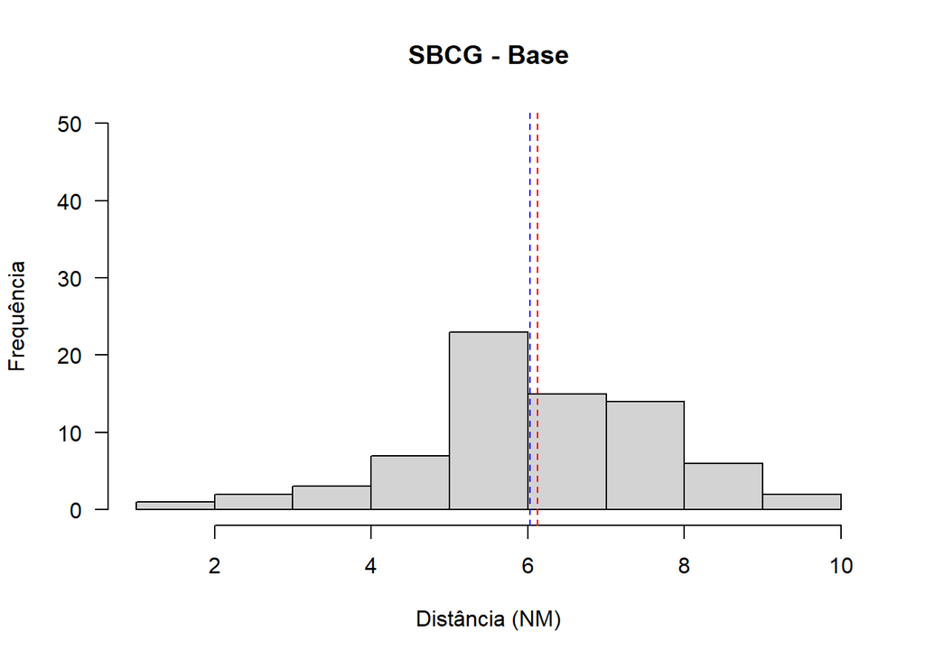

```r
log_Dist <- log2(DF_SAR$Distancia_LKP_Dest)

hist(log_Dist,
     ylim = c(0,50),
     las = 1,
     main = "SBCG - Base",
     xlab = "Distância (NM)",
     ylab = "Frequência")
abline(v = mean(log_Dist), lty = "dashed", col = "red")
abline(v = median(log_Dist), lty = "dashed", col = "blue")
```

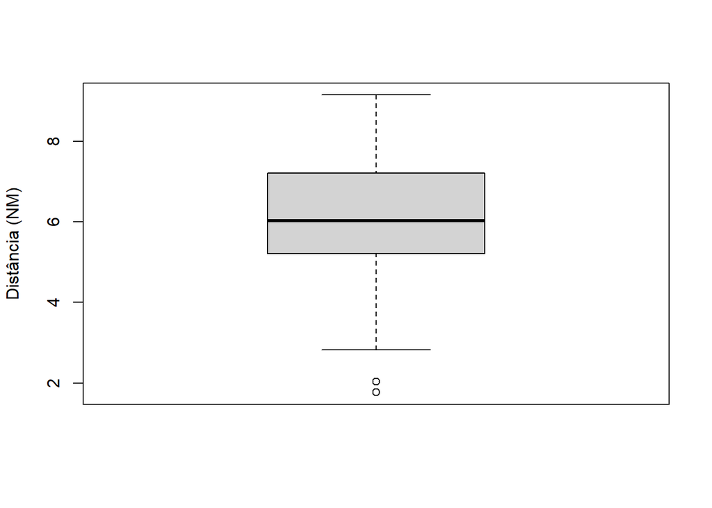

```r
boxplot(log_Dist,
        ylab = "Distância (NM)")
```

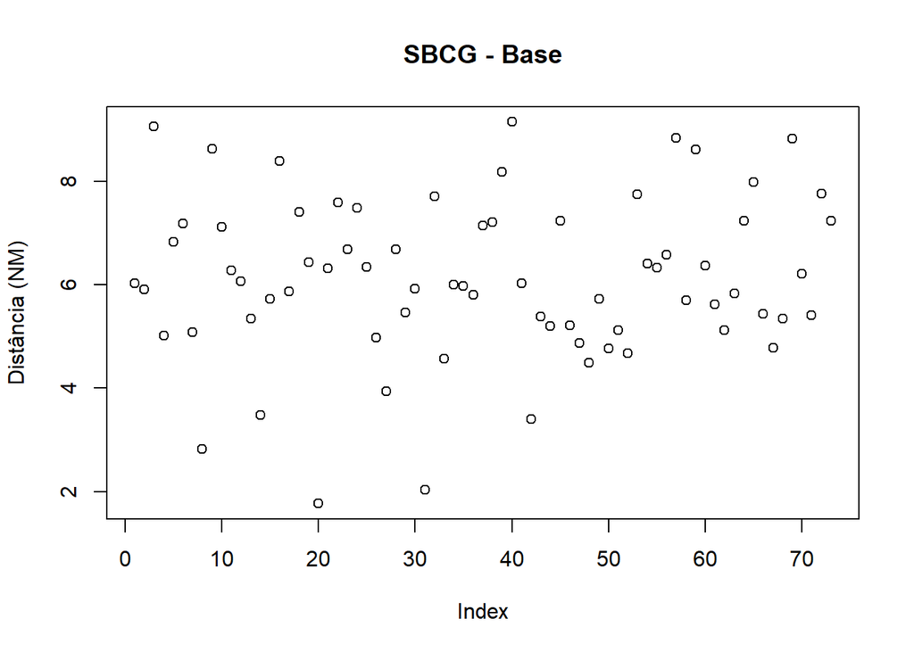

```r
plot(log_Dist,
     main = "SBCG - Base",
      ylab = "Distância (NM)")
```

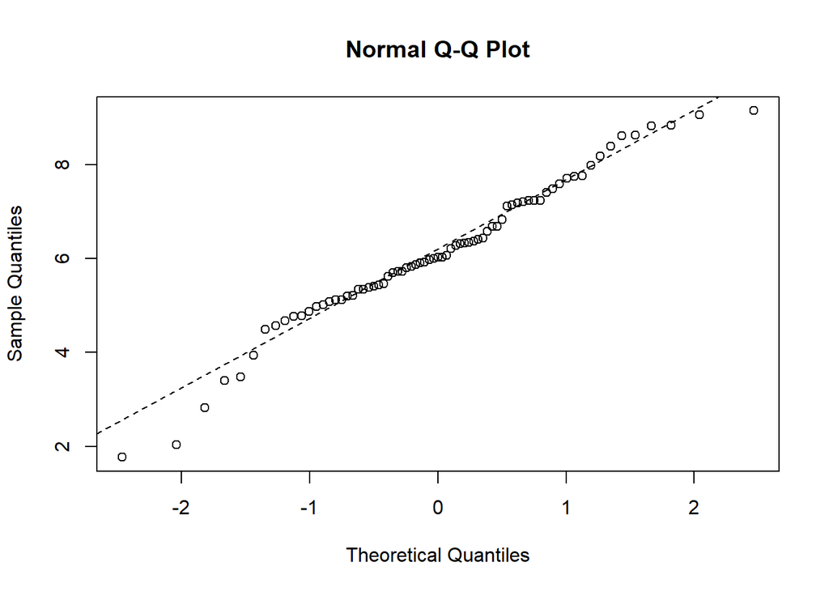

```r
qqnorm(log_Dist)
qqline(log_Dist, lty="dashed") # adiciona reta que passa pelo 1o. e 3o. quartis
```

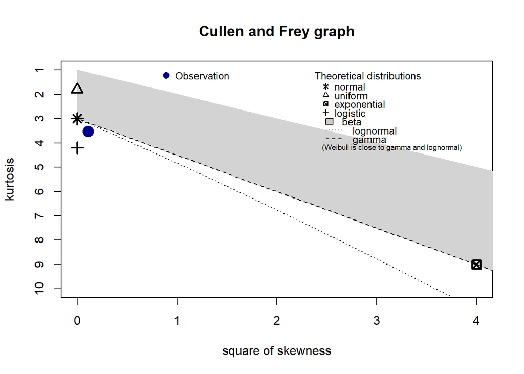

```
## summary statistics
## ------
## min:  1.771987   max:  9.144383
## median:  6.028379
## mean:  6.123581
## estimated sd:  1.53945
## estimated skewness:  -0.3301193
## estimated kurtosis:  3.523792
```

```r
descdist(log_Dist)
```

```r
ks.test(log_Dist, "pnorm")
```

```
##
##  Exact one-sample Kolmogorov-Smirnov test
##
## data:  log_Dist
## D = 0.97021, p-value < 2.2e-16
## alternative hypothesis: two-sided
```

```r
ad.test(log_Dist)
```

```
##
##  Anderson-Darling normality test
##
## data:  log_Dist
## A = 0.45154, p-value = 0.2665
```

```r
lillie.test(log_Dist)
```

```
##
##  Lilliefors (Kolmogorov-Smirnov) normality test
##
## data:  log_Dist
## D = 0.065752, p-value = 0.6067
```

```r
shapiro.test(log_Dist)
```

```
##
##  Shapiro-Wilk normality test
##
## data:  log_Dist
## W = 0.9755, p-value = 0.1662
```

Percebi que a transformação para Log na base 2 ficou adequada e resultou em uma distribuição normal. Só não sei como utilizar o fato de ser log2. Isso terei que pesquisar.

Então, de pendências para o desenvolvimento estão faltando alguns pontos:  
1- Entender como trabalhar com essa transformação.  
2- Simular a rota da aeronave para descobrir se, realmente, existe um caminho ótimo (menor caminho).  
2.1 - Para essa simulação eu preciso checar se, somente com esses dados já será o suficiente para validar a otimização. Ou se será necessário simular mais dados. Para isso, pensei em plotar uma centroide no centro da APG Simulada e colocar os pontos focais nos pontos 3 e 4 (pontos de entrada da aeronave). Assim, tentaria trabalhar com a equação da elipse. Essa ideia baseia-se na propriedade de que para qualquer distância entre um ponto na circunferência da elipse e os pontos focais, a distância é a mesma, o que simularia que para qualquer posição da base nessa elipse, a distância percorrida seria a mesma.

Basicamente é isso até aqui.